# Modeling and prediction for movies

While we’re at it, let’s also do a diagnositcs run to make sure it is appropriate for us to use the model. First, let’s do a residuals plot on the model to check for linearity.

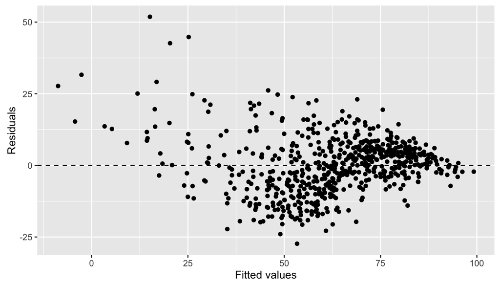

```r
ggplot(data = m6, aes(x = .fitted, y = .resid)) + geom_point() + geom_hline(yintercept = 0, linetype = "dashed") + xlab("Fitted values") + ylab("Residuals")
```

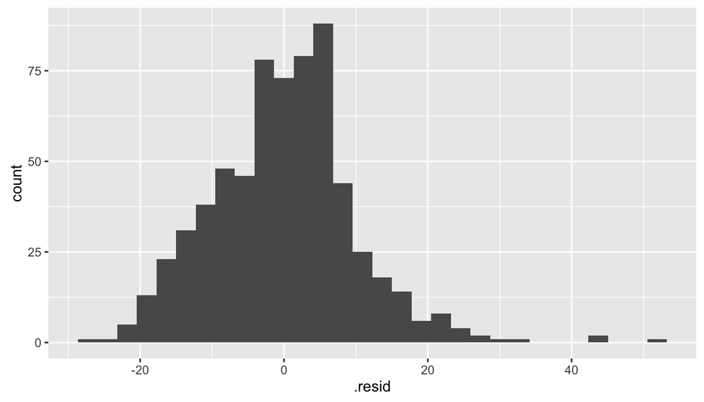

```r
ggplot(data = m6, aes(x = .resid)) + geom_histogram()
```

According to the histogram, we also see what appears to be a nearly normal distribution of the residuals, with a right skew. Let’s also check this condition using a normal probability plot.

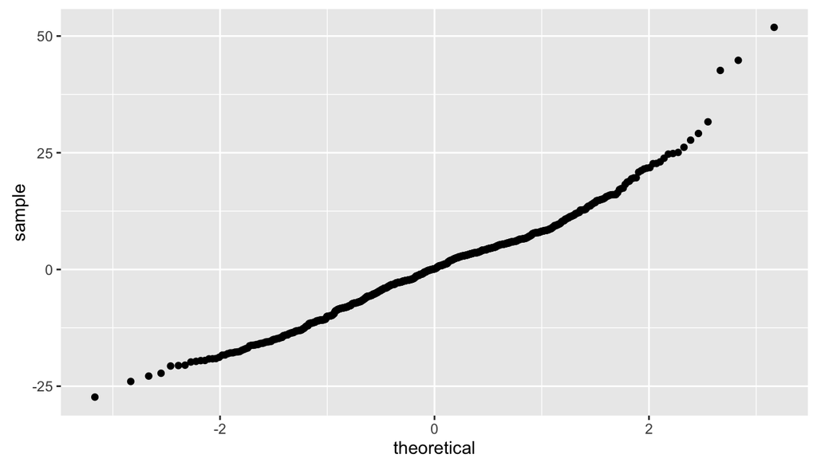

```r
ggplot(data = m6, aes(sample = .resid)) + stat_qq()
```

Moreover, let’s also do a residuals plot for each predictor variable.

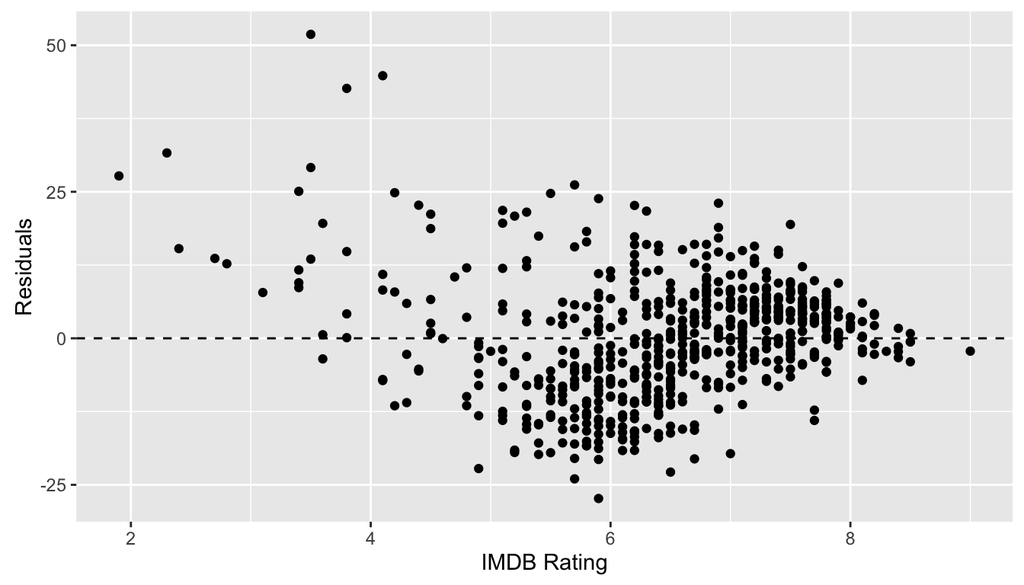

```r
ggplot(data = m6, aes(x = imdb_rating, y = .resid)) + geom_point() + geom_hline(yintercept = 0, linetype = "dashed") + xlab("IMDB Rating") + ylab("Residuals")
```

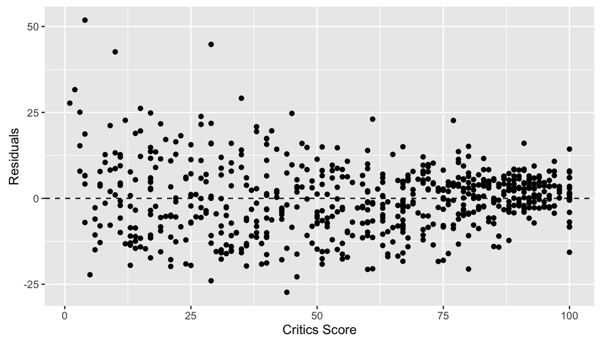

```r
ggplot(data = m6, aes(x = critics_score, y = .resid)) + geom_point() + geom_hline(yintercept = 0, linetype = "dashed") + xlab("Critics Score") + ylab("Residuals")
```

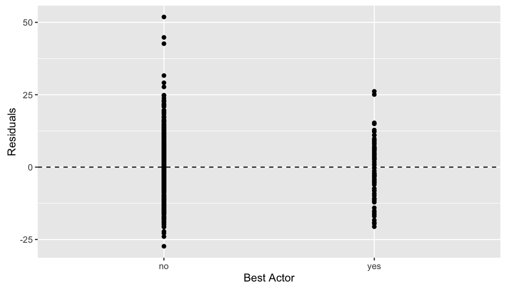

```r
ggplot(data = m6, aes(x = best_actor_win, y = .resid)) + geom_point() + geom_hline(yintercept = 0, linetype = "dashed") + xlab("Best Actor") + ylab("Residuals")
```

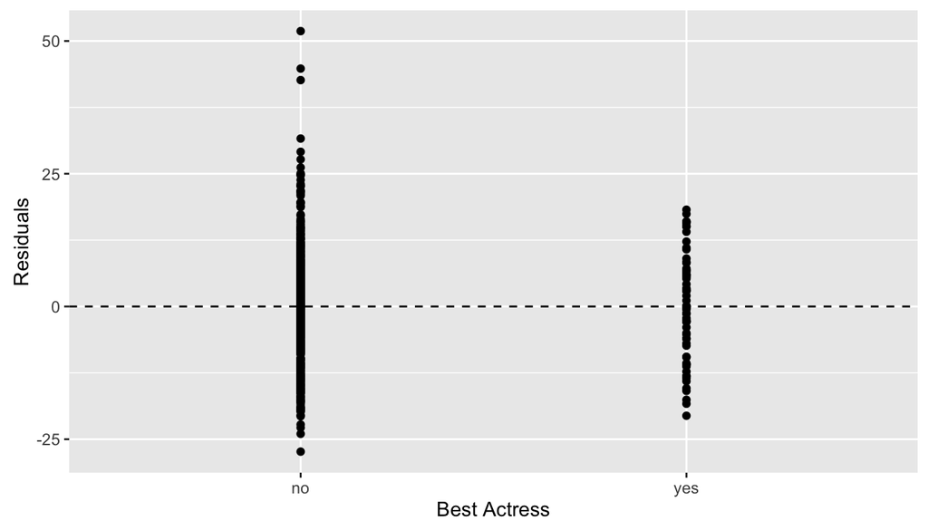

```r
ggplot(data = m6, aes(x = best_actress_win, y = .resid)) + geom_point() + geom_hline(yintercept = 0, linetype = "dashed") + xlab("Best Actress") + ylab("Residuals")
```

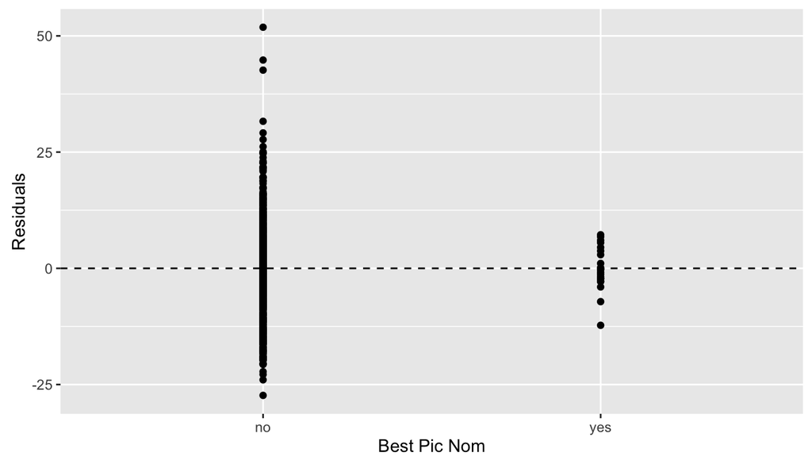

```r
ggplot(data = m6, aes(x = best_pic_nom, y = .resid)) + geom_point() + geom_hline(yintercept = 0, linetype = "dashed") + xlab("Best Pic Nom") + ylab("Residuals")
```

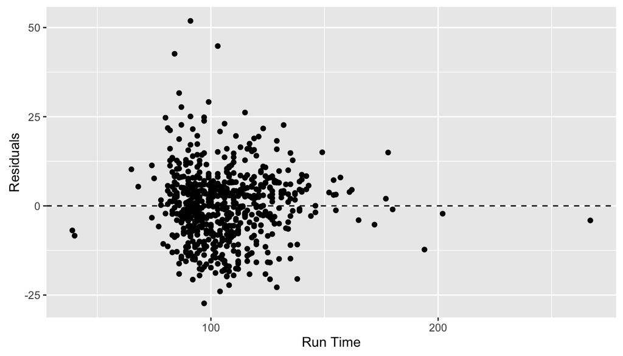

```r
ggplot(data = m6, aes(x = runtime, y = .resid)) + geom_point() + geom_hline(yintercept = 0, linetype = "dashed") + xlab("Run Time") + ylab("Residuals")
```

Finally, for “run time”, there appears to be no underlying pattern here as well here, with no other patterns to account for (i.e., fan-shaped patterns).

## Part 5: Prediction

Note above the movie values we have below for the score. Now let us create a data frame with those predictions. For our predicted movie, we will use Florence Foster Jenkins (2016), using data taken from IMDB and Rotten Tomatoes (searched 8/15/2016). The current IMDB rating is 7.2, the critics score from Rotten Tomatoes is 70. It also includes one best actress winner, Meryl Streep. The run time for the movie is 110 minutes.

```r
m6 <- lm(audience_score ~ runtime + imdb_rating + critics_score + best_actor_win + best_actress_win + best_pic_nom, data = movies)
Flo_Fos <- data.frame(runtime = 110, imdb_rating = 7.2, critics_score = 70, best_actor_win = "no", best_actress_win = "yes", best_pic_nom = "yes")
predict(m6, newdata=Flo_Fos)
```

```
##        1
## 76.72177
```

Let’s also do a confidence interval check here as well for 95%.

```r
predict(m6, Flo_Fos, interval = "prediction", level = 0.95)
```

```
##        fit      lwr      upr
## 1 76.72177 56.53099 96.91254
```

According to our model, we would be 95% confident that the score for audience popularity would be estimated between 56.53 and 96.91 (rounded up).

## Part 6: Conclusion

For our project, we were tasked with helping our boss at Paramount Pictures to identify models that can help predict the success of a movie with the audience. In terms of success, we defined it in terms of the audience score as measured by Rotten Tomatoes, and we took a backwards-elimination approach to creating a model that helps us to predict success.

The model we created does allow us to account for about 75.56% of the observed data. Thus, we would tell our boss that run time, IMDB rating, critics score, best picture nomination, best actress and actor win would be the main things to consider in a model that could predict, about 75.6% of the time, audience’s popularity scores on movies. Again, it is important to note that overall this was a search for the best model, rather than specific predictors.